# Delayed Monetary Losses: Reproducible Analysis in R

Adjusting-Amount and Delayed Losses Questionnaire measures

Author

Haoran Wan

## Scope

This document reproduces the primary measurement-validation analyses reported in:

> Wan, H., Green, L., & Myerson, J. (2024). Delayed monetary losses: Do different procedures and discounting measures assess the same construct? *Behavioural Processes, 222*, 105101. https://doi.org/10.1016/j.beproc.2024.105101

The analysis reproduces Figure 1 and Tables 2-4: group-level model fits, convergent validity between procedures, concurrent validity between scoring measures, alternate-forms reliability across amounts, and consistency of individual discounting patterns. The final section checks the computed results against the values printed in the article.

The anonymized data are archived on the [Open Science Framework](https://osf.io/emb2q/). The repository copy is stored in `data/Data_AdjAmt_DLQ.csv` for computational reproducibility.

## Setup

The workflow intentionally uses base R plus `knitr`, which minimizes dependencies and makes the analysis straightforward to audit.

**Show analysis code**

```r
options(digits = 4, scipen = 5, width = 100)
set.seed(20240913)

locate_data <- function() {
  candidates <- c(
    "data/Data_AdjAmt_DLQ.csv",
    "../data/Data_AdjAmt_DLQ.csv"
  )
  existing <- candidates[file.exists(candidates)]
  if (length(existing) == 0) {
    stop(
      "data/Data_AdjAmt_DLQ.csv was not found. Run from the repository root ",
      "or the Analysis directory."
    )
  }
  normalizePath(existing[[1]])
}

data_path <- locate_data()
amount_order_adj <- c("$90", "$240", "$1,500")
amount_order_dlq <- c("$90", "$165", "$240")
common_amounts <- c("$90", "$240")
pattern_order <- c("Typical", "Always immediate", "Atypical", "Inconsistent")
```

### Analysis functions

**Show analysis code**

```r
auc <- function(delay, subjective_value) {
  order_index <- order(delay)
  x <- delay[order_index] / 108
  y <- subjective_value[order_index]
  sum(diff(x) * (head(y, -1) + tail(y, -1)) / 2)
}

simple_hyperbola <- function(delay, log_k) {
  1 / (1 + exp(log_k) * delay)
}

hyperboloid <- function(delay, log_k, s) {
  1 / (1 + exp(log_k) * delay)^s
}

logistic_growth <- function(log_k, midpoint, slope) {
  1 / (1 + exp(-(log_k - midpoint) * slope))
}

r_squared <- function(observed, predicted) {
  1 - sum((observed - predicted)^2) / sum((observed - mean(observed))^2)
}

score_adj_amt <- function(group) {
  group <- group[order(group$Delay), ]
  objective <- function(log_k) {
    sum((group$RSV - simple_hyperbola(group$Delay, log_k))^2)
  }
  log_k <- optimize(objective, interval = c(-30, 10), tol = 1e-12)$minimum
  data.frame(
    ID = group$ID[[1]],
    Amount = group$Amount[[1]],
    auc_adj_amt = auc(group$Delay, group$RSV),
    logk_adj_amt = log_k
  )
}

canonical_dlq_k <- function(k) {
  ifelse(
    abs(k - 0.00088) < 1e-12, 0.00089,
    ifelse(
      abs(k - 0.0018) < 1e-12, 0.0023,
      ifelse(abs(k - 0.0058) < 1e-12 | abs(k - 0.0059) < 1e-12, 0.0055, k)
    )
  )
}

score_dlq <- function(group) {
  choices <- group$Choice
  raw_k <- group$k_raw
  scoring_k <- canonical_dlq_k(raw_k)
  candidates <- sort(unique(scoring_k))
  consistency <- vapply(
    candidates,
    function(candidate) {
      sum(
        (choices == 0 & scoring_k <= candidate) |
          (choices == 1 & scoring_k >= candidate)
      )
    },
    numeric(1)
  )
  best_candidates <- candidates[consistency == max(consistency)]
  best_raw_k <- raw_k[scoring_k %in% best_candidates]

  data.frame(
    ID = group$ID[[1]],
    Amount = group$Amount[[1]],
    prop_imm_dlq = mean(choices),
    logk_dlq = mean(log(best_raw_k))
  )
}

correlation_row <- function(x, y) {
  complete <- complete.cases(x, y)
  test <- cor.test(x[complete], y[complete], method = "pearson")
  c(r = unname(test$estimate), p = test$p.value, n = sum(complete))
}

format_p <- function(p) {
  ifelse(p < 0.001, "< .001", sprintf("%.3f", p))
}

collapse_patterns <- function(values) {
  if (length(unique(values)) == 1) values[[1]] else "Inconsistent"
}
```

## Data and quality checks

The public file contains the analyzed Prolific sample after the exclusions reported in the article. `Choice = 1` denotes selection of the smaller, immediate payment on the DLQ.

**Show analysis code**

```r
raw <- read.csv(data_path, stringsAsFactors = FALSE, check.names = FALSE)
raw <- raw[, -1]

adj_amt <- subset(raw, Procedure == "Adj-Amt")
names(adj_amt)[names(adj_amt) == "IV"] <- "Delay"
names(adj_amt)[names(adj_amt) == "DV"] <- "RSV"

dlq <- subset(raw, Procedure == "MCQ")
names(dlq)[names(dlq) == "IV"] <- "k_raw"
names(dlq)[names(dlq) == "DV"] <- "Choice"
dlq$Procedure <- "DLQ"
dlq$Amount <- unname(c(
  "$75-$105" = "$90",
  "$150-$180" = "$165",
  "$225-$255" = "$240"
)[dlq$Amount])

stopifnot(
  length(unique(raw$ID)) == 431,
  nrow(adj_amt) == 5172,
  nrow(dlq) == 11637,
  identical(sort(unique(adj_amt$Delay)), c(4, 18, 60, 108)),
  identical(sort(unique(dlq$Choice)), c(0, 1)),
  all(table(adj_amt$ID, adj_amt$Amount) == 4),
  all(table(dlq$ID, dlq$Amount) == 9)
)

data.frame(
  procedure = c("Adjusting-Amount", "DLQ"),
  participants = c(length(unique(adj_amt$ID)), length(unique(dlq$ID))),
  observations = c(nrow(adj_amt), nrow(dlq)),
  amount_conditions = c(3, 3),
  observations_per_participant_amount = c(4, 9)
)
```

```
         procedure participants observations amount_conditions observations_per_participant_amount
1 Adjusting-Amount          431         5172                 3                                   4
2              DLQ          431        11637                 3                                   9
```

## Individual discounting scores

For the Adj-Amt procedure, the atheoretical measure is area under the curve (AuC), and the theoretical measure is the logarithm of the best-fitting *k* from a simple hyperbola. For the DLQ, the corresponding measures are immediate-choice proportion and the logarithm of the *k* value most consistent with the participant’s choices.

For delayed losses, lower AuC and lower immediate-choice proportion indicate steeper discounting, whereas lower log(*k*) indicates shallower discounting. Consequently, concurrent correlations between atheoretical and theoretical measures are expected to be negative.

**Show analysis code**

```r
adj_groups <- split(adj_amt, interaction(adj_amt$ID, adj_amt$Amount, drop = TRUE))
adj_scores <- do.call(rbind, lapply(adj_groups, score_adj_amt))
row.names(adj_scores) <- NULL

dlq_groups <- split(dlq, interaction(dlq$ID, dlq$Amount, drop = TRUE))
dlq_scores <- do.call(rbind, lapply(dlq_groups, score_dlq))
row.names(dlq_scores) <- NULL

stopifnot(nrow(adj_scores) == 431 * 3, nrow(dlq_scores) == 431 * 3)
```

## Group-level discounting (Figure 1)

**Show analysis code**

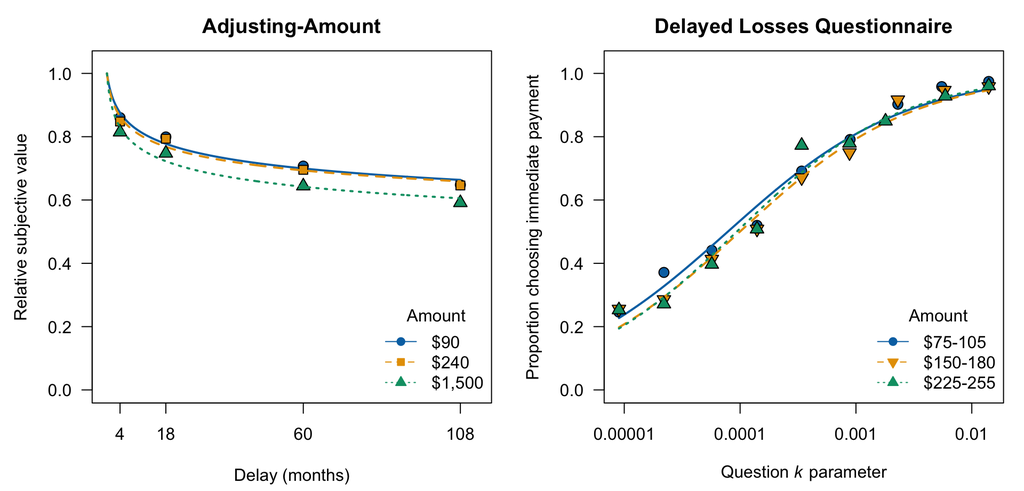

Group-level replication of Figure 1. Points are observed means; lines are the fitted hyperboloid (Adj-Amt) and logistic growth (DLQ) functions.

```r
adj_group <- aggregate(RSV ~ Amount + Delay, adj_amt, mean)
dlq_group <- aggregate(Choice ~ Amount + k_raw, dlq, mean)

colors_adj <- c("$90" = "#0072B2", "$240" = "#E69F00", "$1,500" = "#009E73")
symbols_adj <- c("$90" = 21, "$240" = 22, "$1,500" = 24)
line_types_adj <- c("$90" = 1, "$240" = 2, "$1,500" = 3)

adj_fits <- list()
adj_r2 <- numeric(length(amount_order_adj))
names(adj_r2) <- amount_order_adj
for (amount in amount_order_adj) {
  group <- subset(adj_group, Amount == amount)
  objective <- function(parameters) {
    sum((group$RSV - hyperboloid(group$Delay, parameters[[1]], parameters[[2]]))^2)
  }
  fit <- optim(c(-4, 1), objective, method = "Nelder-Mead", control = list(reltol = 1e-12))
  adj_fits[[amount]] <- fit$par
  adj_r2[[amount]] <- r_squared(
    group$RSV,
    hyperboloid(group$Delay, fit$par[[1]], fit$par[[2]])
  )
}

dlq_colors <- c("$90" = "#0072B2", "$165" = "#E69F00", "$240" = "#009E73")
dlq_symbols <- c("$90" = 21, "$165" = 25, "$240" = 24)
dlq_line_types <- c("$90" = 1, "$165" = 2, "$240" = 3)
dlq_labels <- c("$90" = "$75-105", "$165" = "$150-180", "$240" = "$225-255")

dlq_fits <- list()
dlq_r2 <- numeric(length(amount_order_dlq))
names(dlq_r2) <- amount_order_dlq
for (amount in amount_order_dlq) {
  group <- subset(dlq_group, Amount == amount)
  log_k <- log(group$k_raw)
  objective <- function(parameters) {
    sum((group$Choice - logistic_growth(log_k, parameters[[1]], parameters[[2]]))^2)
  }
  fit <- optim(c(-10, 1), objective, method = "Nelder-Mead", control = list(reltol = 1e-12))
  dlq_fits[[amount]] <- fit$par
  dlq_r2[[amount]] <- r_squared(
    group$Choice,
    logistic_growth(log_k, fit$par[[1]], fit$par[[2]])
  )
}

old_par <- par(mfrow = c(1, 2), mar = c(4.3, 4.5, 2.5, 1), las = 1)
plot(
  NA, xlim = c(0, 113), ylim = c(0, 1.03), xaxt = "n",
  xlab = "Delay (months)", ylab = "Relative subjective value",
  main = "Adjusting-Amount"
)
axis(1, at = c(4, 18, 60, 108))
for (amount in amount_order_adj) {
  group <- subset(adj_group, Amount == amount)
  points(
    group$Delay, group$RSV, pch = symbols_adj[[amount]], bg = colors_adj[[amount]],
    col = "black", cex = 1.3
  )
  x_grid <- seq(0, 108, length.out = 300)
  parameters <- adj_fits[[amount]]
  lines(
    x_grid, hyperboloid(x_grid, parameters[[1]], parameters[[2]]),
    col = colors_adj[[amount]], lty = line_types_adj[[amount]], lwd = 2
  )
}
legend(
  "bottomright", legend = amount_order_adj, pch = symbols_adj, pt.bg = colors_adj,
  col = colors_adj, lty = line_types_adj, bty = "n", title = "Amount"
)

plot(
  NA, xlim = range(log(dlq_group$k_raw)), ylim = c(0, 1.03), xaxt = "n",
  xlab = expression(paste("Question ", italic(k), " parameter")),
  ylab = "Proportion choosing immediate payment",
  main = "Delayed Losses Questionnaire"
)
axis(1, at = log(c(0.00001, 0.0001, 0.001, 0.01)), labels = c("0.00001", "0.0001", "0.001", "0.01"))
for (amount in amount_order_dlq) {
  group <- subset(dlq_group, Amount == amount)
  points(
    log(group$k_raw), group$Choice, pch = dlq_symbols[[amount]],
    bg = dlq_colors[[amount]], col = "black", cex = 1.3
  )
  x_grid <- seq(min(log(group$k_raw)), max(log(group$k_raw)), length.out = 300)
  parameters <- dlq_fits[[amount]]
  lines(
    x_grid, logistic_growth(x_grid, parameters[[1]], parameters[[2]]),
    col = dlq_colors[[amount]], lty = dlq_line_types[[amount]], lwd = 2
  )
}
legend(
  "bottomright", legend = dlq_labels, pch = dlq_symbols, pt.bg = dlq_colors,
  col = dlq_colors, lty = dlq_line_types, bty = "n", title = "Amount"
)
```

**Show analysis code**

```r
par(old_par)

model_fit <- rbind(
  data.frame(procedure = "Adj-Amt", amount = names(adj_r2), R2 = unname(adj_r2)),
  data.frame(procedure = "DLQ", amount = names(dlq_r2), R2 = unname(dlq_r2))
)
knitr::kable(model_fit, digits = 3)
```

| procedure | amount | R2 |
| --- | --- | --- |
| Adj-Amt | $90 | 0.962 |
| Adj-Amt | $240 | 0.957 |
| Adj-Amt | $1,500 | 0.965 |
| DLQ | $90 | 0.984 |
| DLQ | $165 | 0.984 |
| DLQ | $240 | 0.976 |

All group-level fits exceed the thresholds reported in the article: R² > .95 for Adj-Amt and R² > .97 for the DLQ.

## Convergent validity between procedures (Table 2)

Only the two amounts common to both procedures ($90 and $240) enter the primary convergent-validity analysis.

**Show analysis code**

```r
common_scores <- merge(adj_scores, dlq_scores, by = c("ID", "Amount"))
common_scores <- subset(common_scores, Amount %in% common_amounts)

table2_rows <- list()
row_index <- 1
for (amount in common_amounts) {
  group <- subset(common_scores, Amount == amount)
  for (measure in c("AuC / immediate-choice proportion", "log(k)")) {
    values <- if (measure == "log(k)") {
      correlation_row(group$logk_adj_amt, group$logk_dlq)
    } else {
      correlation_row(group$auc_adj_amt, group$prop_imm_dlq)
    }
    table2_rows[[ row_index]] <- data.frame(
      amount = amount,
      measure = measure,
      r = values[["r"]],
      p = values[["p"]],
      n = values[["n"]]
    )
    row_index <- row_index + 1
  }
}
table2 <- do.call(rbind, table2_rows)
table2_display <- transform(table2, p = format_p(p))
knitr::kable(table2_display, digits = 3)
```

| amount | measure | r | p | n |
| --- | --- | --- | --- | --- |
| $90 | AuC / immediate-choice proportion | 0.735 | < .001 | 431 |
| $90 | log(k) | 0.728 | < .001 | 431 |
| $240 | AuC / immediate-choice proportion | 0.777 | < .001 | 431 |
| $240 | log(k) | 0.773 | < .001 | 431 |

## Concurrent validity and alternate-forms reliability (Table 3)

**Show analysis code**

```r
concurrent_rows <- list()
row_index <- 1
for (amount in amount_order_adj) {
  group <- subset(adj_scores, Amount == amount)
  values <- correlation_row(group$auc_adj_amt, group$logk_adj_amt)
  concurrent_rows[[ row_index]] <- data.frame(
    procedure = "Adj-Amt", amount = amount,
    r = values[["r"]], p = values[["p"]], n = values[["n"]]
  )
  row_index <- row_index + 1
}
for (amount in amount_order_dlq) {
  group <- subset(dlq_scores, Amount == amount)
  values <- correlation_row(group$prop_imm_dlq, group$logk_dlq)
  concurrent_rows[[ row_index]] <- data.frame(
    procedure = "DLQ", amount = amount,
    r = values[["r"]], p = values[["p"]], n = values[["n"]]
  )
  row_index <- row_index + 1
}
table3a <- do.call(rbind, concurrent_rows)
table3a_display <- transform(table3a, p = format_p(p))
knitr::kable(table3a_display, digits = 3)
```

| procedure | amount | r | p | n |
| --- | --- | --- | --- | --- |
| Adj-Amt | $90 | -0.960 | < .001 | 431 |
| Adj-Amt | $240 | -0.968 | < .001 | 431 |
| Adj-Amt | $1,500 | -0.962 | < .001 | 431 |
| DLQ | $90 | -0.981 | < .001 | 431 |
| DLQ | $165 | -0.982 | < .001 | 431 |
| DLQ | $240 | -0.977 | < .001 | 431 |

**Show analysis code**

```r
reliability_matrix <- function(scores, value, amount_order) {
  wide <- reshape(
    scores[c("ID", "Amount", value)],
    idvar = "ID", timevar = "Amount", direction = "wide"
  )
  columns <- paste(value, amount_order, sep = ".")
  result <- cor(wide[columns], use = "pairwise.complete.obs")
  dimnames(result) <- list(amount_order, amount_order)
  result
}

table3b_adj <- reliability_matrix(adj_scores, "auc_adj_amt", amount_order_adj)
table3b_dlq <- reliability_matrix(dlq_scores, "prop_imm_dlq", amount_order_dlq)
table3c_adj <- reliability_matrix(adj_scores, "logk_adj_amt", amount_order_adj)
table3c_dlq <- reliability_matrix(dlq_scores, "logk_dlq", amount_order_dlq)

knitr::kable(table3b_adj, digits = 3, caption = "Adj-Amt AuC")
```

Adj-Amt AuC

|  | $90 | $240 | $1,500 |
| --- | --- | --- | --- |
| $90 | 1.000 | 0.782 | 0.636 |
| $240 | 0.782 | 1.000 | 0.763 |
| $1,500 | 0.636 | 0.763 | 1.000 |

**Show analysis code**

```r
knitr::kable(table3b_dlq, digits = 3, caption = "DLQ immediate-choice proportion")
```

DLQ immediate-choice proportion

|  | $90 | $165 | $240 |
| --- | --- | --- | --- |
| $90 | 1.000 | 0.866 | 0.806 |
| $165 | 0.866 | 1.000 | 0.893 |
| $240 | 0.806 | 0.893 | 1.000 |

**Show analysis code**

```r
knitr::kable(table3c_adj, digits = 3, caption = "Adj-Amt log(k)")
```

Adj-Amt log(k)

|  | $90 | $240 | $1,500 |
| --- | --- | --- | --- |
| $90 | 1.000 | 0.797 | 0.628 |
| $240 | 0.797 | 1.000 | 0.761 |
| $1,500 | 0.628 | 0.761 | 1.000 |

**Show analysis code**

```r
knitr::kable(table3c_dlq, digits = 3, caption = "DLQ log(k)")
```

DLQ log(k)

|  | $90 | $165 | $240 |
| --- | --- | --- | --- |
| $90 | 1.000 | 0.836 | 0.747 |
| $165 | 0.836 | 1.000 | 0.840 |
| $240 | 0.747 | 0.840 | 1.000 |

## Individual discounting patterns (Table 4)

Patterns are classified separately for the $90 and $240 conditions, then combined within each procedure. “Inconsistent” means that a participant received different classifications for the two amounts.

**Show analysis code**

```r
classify_adj_group <- function(group) {
  correlation_value <- suppressWarnings(cor(group$RSV, log(group$Delay)))
  if (is.na(correlation_value)) correlation_value <- 0
  mean_value <- mean(group$RSV)
  if (correlation_value < 0 || isTRUE(all.equal(mean_value, min(adj_amt$RSV)))) {
    "Typical"
  } else if (correlation_value > 0) {
    "Atypical"
  } else if (isTRUE(all.equal(mean_value, max(adj_amt$RSV)))) {
    "Always immediate"
  } else {
    "Typical"
  }
}

classify_dlq_group <- function(group) {
  # Pattern classification uses each item's original k, as in the article.
  correlation_value <- suppressWarnings(cor(group$Choice, log(group$k_raw)))
  if (is.na(correlation_value)) correlation_value <- 0
  mean_choice <- mean(group$Choice)
  if (correlation_value > 0 || isTRUE(all.equal(mean_choice, 0))) {
    "Typical"
  } else if (correlation_value < 0) {
    "Atypical"
  } else if (isTRUE(all.equal(mean_choice, 1))) {
    "Always immediate"
  } else {
    "Unclassified"
  }
}

adj_pattern_data <- subset(adj_amt, Amount %in% common_amounts)
adj_pattern_groups <- split(
  adj_pattern_data,
  interaction(adj_pattern_data$ID, adj_pattern_data$Amount, drop = TRUE)
)
adj_amount_patterns <- do.call(
  rbind,
  lapply(adj_pattern_groups, function(group) {
    data.frame(ID = group$ID[[1]], Amount = group$Amount[[1]], pattern = classify_adj_group(group))
  })
)

dlq_pattern_data <- subset(dlq, Amount %in% common_amounts)
dlq_pattern_groups <- split(
  dlq_pattern_data,
  interaction(dlq_pattern_data$ID, dlq_pattern_data$Amount, drop = TRUE)
)
dlq_amount_patterns <- do.call(
  rbind,
  lapply(dlq_pattern_groups, function(group) {
    data.frame(ID = group$ID[[1]], Amount = group$Amount[[1]], pattern = classify_dlq_group(group))
  })
)

adj_patterns <- aggregate(pattern ~ ID, adj_amount_patterns, collapse_patterns)
names(adj_patterns)[[2]] <- "Adj_Amt"
dlq_patterns <- aggregate(pattern ~ ID, dlq_amount_patterns, collapse_patterns)
names(dlq_patterns)[[2]] <- "DLQ"
patterns <- merge(adj_patterns, dlq_patterns, by = "ID")

table4 <- table(
  `Adj-Amt` = factor(patterns$Adj_Amt, levels = pattern_order),
  DLQ = factor(patterns$DLQ, levels = pattern_order)
)
knitr::kable(table4, caption = "Cross-tabulation of individual discounting patterns")
```

Cross-tabulation of individual discounting patterns

|  | Typical | Always immediate | Atypical | Inconsistent |
| --- | --- | --- | --- | --- |
| Typical | 255 | 1 | 1 | 12 |
| Always immediate | 5 | 56 | 0 | 10 |
| Atypical | 5 | 2 | 0 | 1 |
| Inconsistent | 62 | 8 | 0 | 13 |

**Show analysis code**

```r
expected <- outer(rowSums(table4), colSums(table4)) / sum(table4)
# The article's test counts matching Typical and Always-immediate patterns.
# Atypical and Inconsistent classifications are not counted as matches.
observed_same <- table4["Typical", "Typical"] +
  table4["Always immediate", "Always immediate"]
expected_same <- expected["Typical", "Typical"] +
  expected["Always immediate", "Always immediate"]
published_chi_square <- (observed_same - expected_same)^2 / expected_same
published_p <- pchisq(published_chi_square, df = 1, lower.tail = FALSE)

data.frame(
  observed_same = observed_same,
  expected_same = expected_same,
  same_pattern_proportion = observed_same / nrow(patterns),
  chi_square = published_chi_square,
  df = 1,
  p = format_p(published_p)
) |>
  knitr::kable(digits = 3, caption = "Published same-pattern consistency test")
```

Published same-pattern consistency test

| observed_same | expected_same | same_pattern_proportion | chi_square | df | p |
| --- | --- | --- | --- | --- | --- |
| 311 | 215.1 | 0.722 | 42.73 | 1 | < .001 |

## Reproduction checks

These assertions fail if future code or data changes no longer reproduce the article within rounding tolerance.

**Show analysis code**

```r
published_table2 <- c(0.735, 0.728, 0.777, 0.773)
stopifnot(all(abs(table2$r - published_table2) <= 0.0006))

published_table4 <- matrix(
  c(
    255, 1, 1, 12,
    5, 56, 0, 10,
    5, 2, 0, 1,
    62, 8, 0, 13
  ),
  nrow = 4,
  byrow = TRUE
)
stopifnot(
  all(as.matrix(table4) == published_table4),
  abs(published_chi_square - 42.7) <= 0.1,
  abs(observed_same / nrow(patterns) - 0.722) <= 0.0005
)

cat("All primary results reproduce the published values within rounding tolerance.\n")
```

```
All primary results reproduce the published values within rounding tolerance.
```

## Computational environment

**Show analysis code**